# A3: Incarceration

### Introduction

The issue of incarceration rates and its disproportionate impact on different racial groups has long been a subject of concern and scrutiny in the United States. To delve into this critical aspect of criminal justice, I chose the dataset about prison/jail population per 100,000 people (rate) per county/state starting at 1990. to explore and compare the rates of incarceration between White and Black populations across various regions.

### Summary Information

The data reveals significant disparities in prison incarceration rates across counties from 1990 to 2018, with the average total prison incarceration rate standing at 585.9841. The data shows that the average black prison incarceration rate in 1990 was alarmingly high at 2028.648, while the average white prison incarceration rate was substantially lower at 249.4197. This contrast emphasizes the pressing issue of racial inequity within the justice system, warranting urgent attention and comprehensive reforms. The identification of specific counties with the highest black and white incarceration rates, such as Mitchell County, North Carolina, and McPherson County, Nebraska, respectively, underscores localized pockets of injustice that necessitate targeted intervention.

### The Dataset

The data was released by Vera Institute of Justice, and it was collected by the U.S. Department of Justice Bureau of Justice Statistics(BJS) from the Census of Jails and the Annual Survey of Jails. The primary objective of gathering this data is to furnish detailed information on prison and jail incarceration rates and related metrics at the county level, spanning across different periods, encompassing the entire United States.There are 91031 observations and 23 features in the data I chose. When working with incarceration data, it is important to be aware of ethical concerns related to racial and socioeconomic biases in the criminal justice system. For instance, disparities in arrests and convictions based on race could lead to an unfair representation in the dataset. It’s crucial to approach the analysis with caution, so we don’t perpetuate harmful stereotypes or reinforce existing injustices. The data has its limitations, too. Missing or incomplete information from various jurisdictions can introduce biases. Therefore, it’s essential to approach this data with care, recognizing its limitations and striving for a more comprehensive understanding of the complex issue of incarceration rates

### Trends Over Time Chart

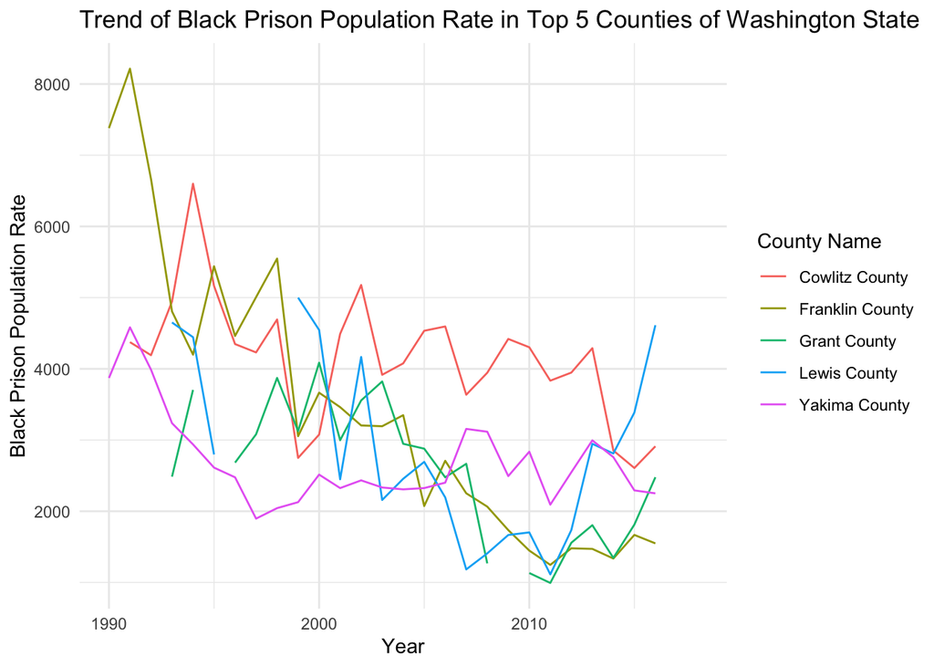

```r
chart1
```

This chart displays how the Black Prison Population Rate has changed over the years in each of the top 5 counties in Washington State. This allows us to observe any upward or downward trends in incarceration rates for the Black population in these regions. From the chart, we can see that even though there are some fluctuations, there’s a trend of decreasing of the black prison population rate through the year 1990 to 2018. Particularly, Franklin County has the most decrease of the rate.

### Variable Comparison Chart

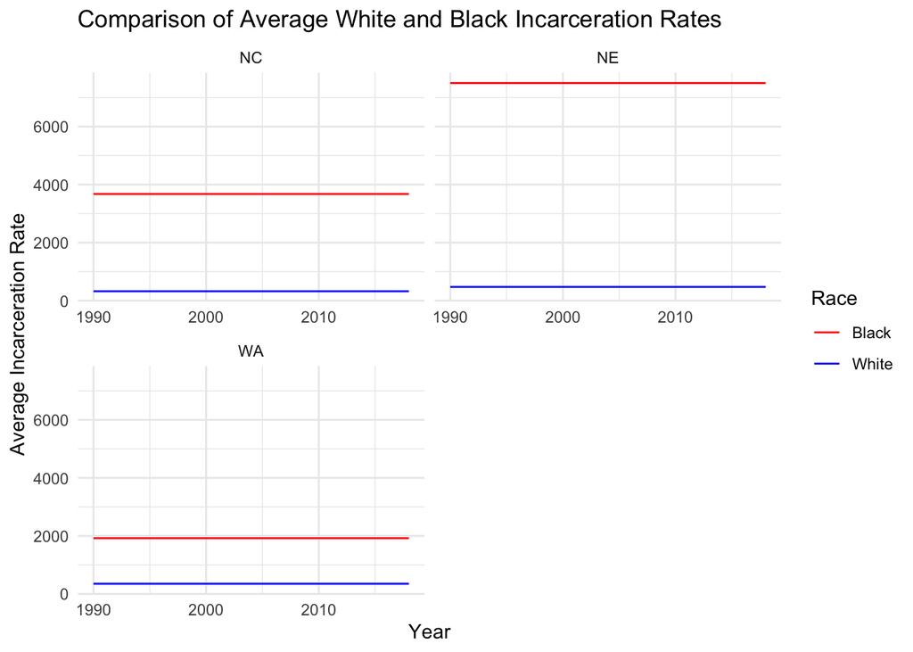

```r
chart2
```

This chart illustrates the relationship between two different continuous variables: the average White and Black incarceration rates across three states: North Carolina, Nebraska, and Washington. The chart displays the average incarceration rates for both racial groups over the years. The comparison helps us identify and communicate any trends or patterns in the dataset. According to the chart, Black incarceration rates are all significantly higher than the White incarceration rates in three states. NC is the state where the county with the maximum black prison rate is and NE is the state where the conuty with the maximum white prison rate is. However, interestingly, the average black incarceration rates of NE is much higher that that of NC.

### Map

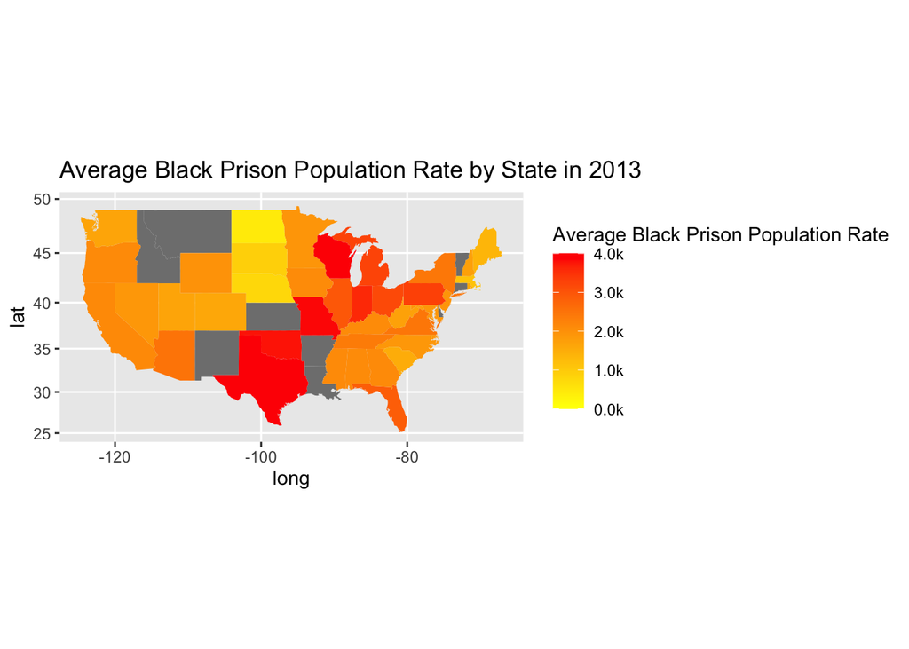

```r
black_prison_pop_by_state_map
```

This map helps us to visualize and compare the geographical distribution of average black prison population rate by state in 2013. I use a yellow-red color ramp. It shows that states such as Texas has the highest average black prison population rate in 2013, and states that are in upper north have relatively low rates.